# Pokemon Dataset

Hasan Arcas

13/10/2021

### Some data taken and processed by using a 801x44 dataset about pokemons.

```r
pokemon <- read.csv("./datasets/pokemon.csv")
head(pokemon)
```

```
##                     abilities against_bug against_dark against_dragon
## 1 ['Overgrow', 'Chlorophyll']        1.00            1              1
## 2 ['Overgrow', 'Chlorophyll']        1.00            1              1
## 3 ['Overgrow', 'Chlorophyll']        1.00            1              1
## 4    ['Blaze', 'Solar Power']        0.50            1              1
## 5    ['Blaze', 'Solar Power']        0.50            1              1
## 6    ['Blaze', 'Solar Power']        0.25            1              1
##   against_electric against_fairy against_fight against_fire against_flying
## 1              0.5           0.5           0.5          2.0              2
## 2              0.5           0.5           0.5          2.0              2
## 3              0.5           0.5           0.5          2.0              2
## 4              1.0           0.5           1.0          0.5              1
## 5              1.0           0.5           1.0          0.5              1
## 6              2.0           0.5           0.5          0.5              1
##   against_ghost against_grass against_ground against_ice against_normal
```

[output cut: 41 more lines]

### But we have some problems with the dataset, there is too much unneccessary attributes, and our attributes types (int, chr…) are not shown, let’s fix that

```r
pokemon_df <- as_tibble(select(pokemon, pokedex_number, name, type1, attack, defense, hp, generation, is_legendary))

sorted_non_legendary_first_and_second_generation <- pokemon_df %>%
  filter(is_legendary==0 & (generation==1 | generation==2)) %>%
  mutate(total_points = attack + defense + hp) %>%
  arrange(desc(total_points))

sorted_non_legendary_first_and_second_generation
```

```
## # A tibble: 240 x 9
##    pokedex_number name      type1  attack defense    hp generation is_legendary
##             <int> <chr>     <chr>   <int>   <int> <int>      <int>        <int>
##  1            208 Steelix   steel     125     230    75          2            0
##  2            248 Tyranitar rock      164     150   100          2            0
##  3            214 Heracross bug       185     115    80          2            0
##  4            212 Scizor    bug       150     140    70          2            0
##  5            130 Gyarados  water     155     109    95          1            0
##  6            112 Rhydon    ground    130     120   105          1            0
##  7             80 Slowbro   water      75     180    95          1            0
##  8            127 Pinsir    bug       155     120    65          1            0
##  9            143 Snorlax   normal    110      65   160          1            0
## 10             76 Golem     rock      120     130    80          1            0
## # ... with 230 more rows, and 1 more variable: total_points <int>
```

### This looks much better than before, we have eliminated most of the columns, we have selected just the non legendary pokemons who are in the first or the second generation and we have even added a new column to reach the total points of each pokemon, in order to sort them by their total points. Next thing to do is to create some plots…

### Let’s see how many pokemon belong to each type

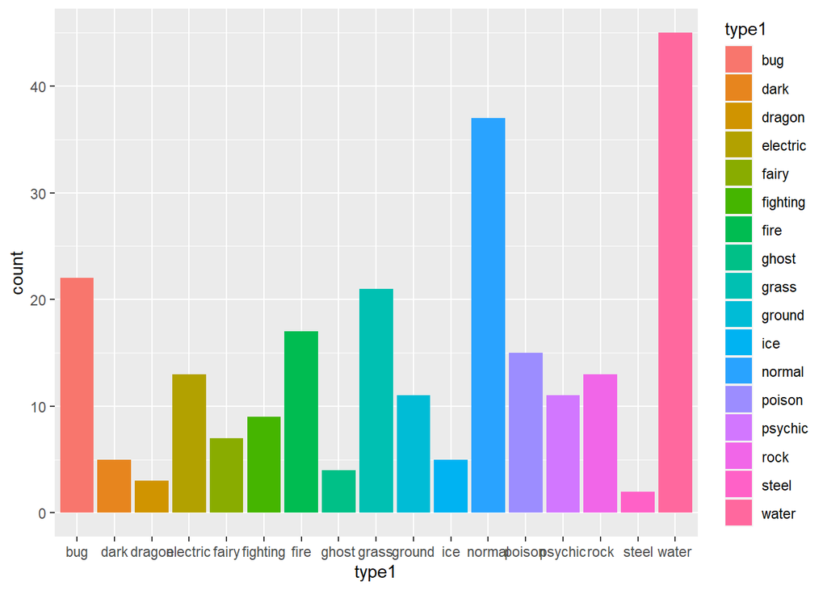

```r
ggplot(sorted_non_legendary_first_and_second_generation) +
  geom_bar(mapping=aes(x = type1, fill= type1))
```

### Now, let’s see if there is a correlation between attack points and the total points

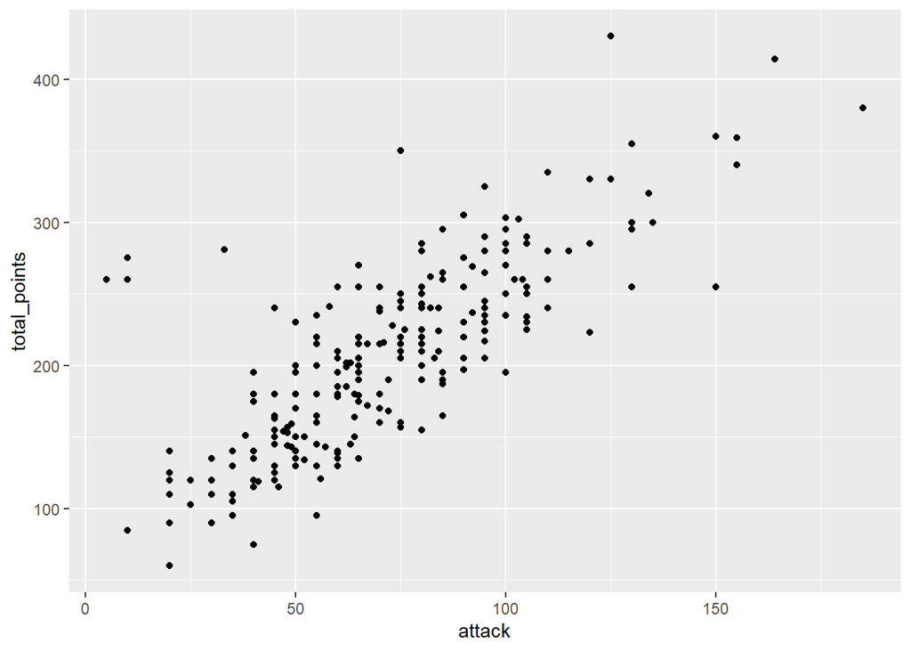

```r
ggplot(sorted_non_legendary_first_and_second_generation) +
  geom_point(mapping=aes(x= attack, y=total_points))
```

### As we could have predicted, there is a positive correlation between attack and total points, but there are some pokemon that have really low attack points, but decent total points.

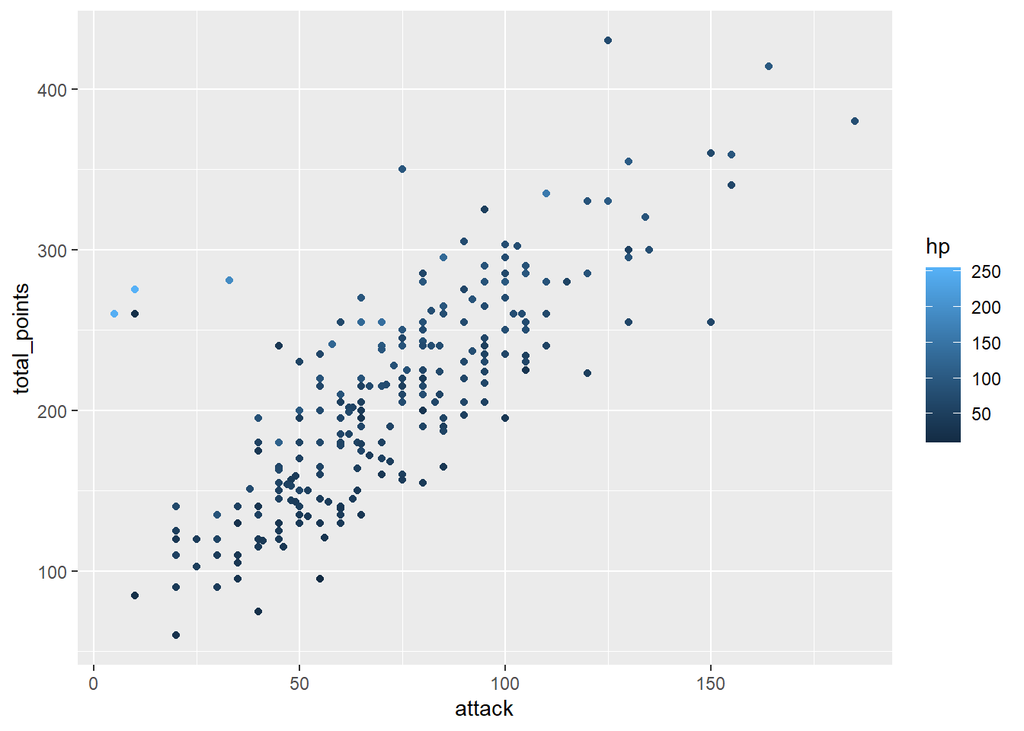

```r
ggplot(sorted_non_legendary_first_and_second_generation) +
  geom_point(mapping=aes(x= attack, y=total_points, color=hp))
```